# Assignment 3

Revanth Ramesh Naidu (revanth.naidu01@estudiant.upf.edu)

Last update: 24 March, 2026

This practical continues our analysis of the dataset from the publication [**Proteomic and Metabolomic Characterization of COVID-19 Patient Sera**](https://www.sciencedirect.com/science/article/pii/S0092867420306279). We work with the training cohort (Supplementary Table 3), which contains proteomic profiles for 31 COVID-19 patients (13 Severe and 18 Non-severe), measured across 791 protein features. The goal of this assignment is to build and evaluate a machine learning classifier to distinguish Severe from Non-severe patients based on their proteomic profiles, identify the most important protein features driving the classification, and validate the model on an independent test cohort (Supplementary Table 4, 10 patients).

# Exercise 1

**Build a Random Forest model to classify COVID-19 severity**

Using the training cohort provided in Supplementary Table 3, build a Random Forest classification model similar to the one in the publication to distinguish between non-Severe and Severe COVID-19 patients.

Report the following performance metrics from cross-validation:

- Confusion matrix
- Accuracy
- ROC curve and AUC

How well does the Random Forest model separate non-Severe from Severe patients based on proteomic profiles?

```r
# ==========================================
# CHUNK 1: Data Import
# ==========================================
if (!requireNamespace("readxl", quietly = TRUE)) {
  install.packages("readxl")
}
library(readxl)

# Automatically set working directory to the script's location (requires RStudio)
if (requireNamespace("rstudioapi", quietly = TRUE) && rstudioapi::isAvailable()) {
  setwd(dirname(rstudioapi::getActiveDocumentContext()$path))
}

# Import proteomics data
df <- read_excel("mmc3.xlsx", sheet = "Prot_and_meta_matrix", col_names = FALSE)

# KEEP ONLY PROTEINS: Subset to rows 1 through 793 (metabolites start at 794)
df <- df[1:793, ]

# Drop column 2
df <- df[, -2]

# Move cell (1,1) to (2,1), remove row 1, set new row 1 as colnames, then remove it
df[2, 1] <- df[1, 1]
df <- df[-1, ]
colnames(df) <- as.character(df[1, ])
df <- df[-1, ]


# ==========================================
# CHUNK 2: Filtering (NO GLOBAL IMPUTATION)
# ==========================================
# To prevent data leakage, we ONLY perform basic missingness filtering here.
# Imputation and scaling are deferred to the CV resampling loop in Chunk 4.

# Convert patient columns to numeric
df[, -1] <- lapply(df[, -1], as.numeric)

# 1. Filter rows (Proteins/Metabolites) with > 20% missing values
row_missing_frac <- rowMeans(is.na(df[, -1]))
df <- df[row_missing_frac <= 0.20, ]

# 2. Filter columns (Patients) with > 20% missing values
col_missing_frac <- colMeans(is.na(df[, -1]))
df <- df[, c(TRUE, col_missing_frac <= 0.20)]


# ==========================================
# CHUNK 3: Import Metadata and Map to Proteomics Data
# ==========================================
# 1. Import the metadata file
labels_raw <- read_excel("data.xlsx", sheet = "Clinical_information")

# 2. Extract Column 1 (Patient IDs) and Column 5 (Severity scores)
meta_labels <- labels_raw[, c(1, 5)]

# Rename columns to make them easier to work with
colnames(meta_labels) <- c("PatientID", "Severity")
meta_labels$Severity <- as.numeric(meta_labels$Severity)

# 3. Filter rows: Keep only values 2 and 3
meta_labels <- meta_labels[meta_labels$Severity %in% c(2, 3), ]

# 4. Recode 2 as "non-Severe" and 3 as "Severe"
meta_labels$Severity <- ifelse(meta_labels$Severity == 2, "non-Severe", "Severe")

# 5. Map labels to the proteomics dataframe (df)
# Get the patient IDs currently in our proteomics dataframe (excluding column 1)
df_patients <- colnames(df)[-1]

# Find the intersection (patients that exist in BOTH 'df' and 'meta_labels')
common_patients <- intersect(df_patients, meta_labels$PatientID)

# Filter 'meta_labels' to only include the common patients
meta_labels <- meta_labels[meta_labels$PatientID %in% common_patients, ]

# Filter 'df' to keep the first column ("Protein/Metabolites") AND the common patients
df <- df[, c(colnames(df)[1], common_patients)]

# Print a quick check
cat("Number of matched patients:", length(common_patients), "\n")
```

```
Number of matched patients: 31
```

```r
head(meta_labels)
```

```
# A tibble: 6 × 2
  PatientID Severity
  <chr>     <chr>
1 XG1       non-Severe
2 XG2       non-Severe
3 XG3       non-Severe
4 XG4       non-Severe
5 XG5       non-Severe
6 XG6       non-Severe
```

```r
# ==========================================
# CHUNK 4: Random Forest Modeling & Evaluation
# ==========================================
# Install and load required packages
if (!requireNamespace("caret", quietly = TRUE)) install.packages("caret")
if (!requireNamespace("randomForest", quietly = TRUE)) install.packages("randomForest")
if (!requireNamespace("pROC", quietly = TRUE)) install.packages("pROC")
if (!requireNamespace("ggplot2", quietly = TRUE)) install.packages("ggplot2")
if (!requireNamespace("doParallel", quietly = TRUE)) install.packages("doParallel")

# Add Bioconductor packages for ID mapping
if (!requireNamespace("BiocManager", quietly = TRUE)) install.packages("BiocManager")
if (!requireNamespace("AnnotationDbi", quietly = TRUE)) BiocManager::install("AnnotationDbi", update = FALSE)
if (!requireNamespace("org.Hs.eg.db", quietly = TRUE)) BiocManager::install("org.Hs.eg.db", update = FALSE)

library(caret)
library(randomForest)
library(pROC)
library(ggplot2)
library(doParallel)
library(AnnotationDbi)
library(org.Hs.eg.db)

# 1. Prepare data for modeling (Transpose and Map IDs)
original_features <- as.character(df[[1]])

# Attempt to map UniProt IDs to HGNC Symbols
# (Metabolites and unmapped proteins will safely return NA)
suppressMessages({
  mapped_symbols <- mapIds(
    org.Hs.eg.db,
    keys = original_features,
    column = "SYMBOL",
    keytype = "UNIPROT",
    multiVals = "first"
  )
})

# Replace with HGNC symbol if a mapping was found, otherwise keep original name
updated_features <- ifelse(is.na(mapped_symbols), original_features, mapped_symbols)

# R models require valid column names without spaces or special characters
valid_protein_names <- make.names(updated_features, unique = TRUE)

# Transpose dataframe (exclude the first column of IDs)
df_t <- as.data.frame(t(df[, -1]))
colnames(df_t) <- valid_protein_names

# Add PatientID back in for merging
df_t$PatientID <- rownames(df_t)

# 2. Merge labels and transposed proteomics data
# Set explicitly to factors with "Severe" as the first level (the positive class)
meta_labels$Severity <- factor(gsub("-", "_", meta_labels$Severity), levels = c("Severe", "non_Severe"))
model_data <- merge(meta_labels, df_t, by = "PatientID")

# Drop the PatientID column as it shouldn't be used as a predictor feature
model_data$PatientID <- NULL


# 3. Set up Parallel Processing (Allocate 6 Cores)
cat("\nSetting up parallel processing with 6 cores...\n")
```

```
Setting up parallel processing with 6 cores...
```

```r
cl <- makePSOCKcluster(6)
registerDoParallel(cl)

# 4. Set up 5-Fold Cross-Validation Repeated 20 Times (Reduced from 100 for speed)
set.seed(123)
# Explicitly namespace trainControl to caret
fitControl <- caret::trainControl(
  method = "repeatedcv",
  number = 5,
  repeats = 20,                        # Reduced from 100 for faster computation
  classProbs = TRUE,                   # Needed for ROC/AUC
  summaryFunction = twoClassSummary,   # Calculates ROC, Sensitivity, Specificity
  savePredictions = "final",           # Keep CV predictions for final probability aggregation
  allowParallel = TRUE                 # Enable parallel processing for caret
)

# 5. Train the Final Random Forest Model (Leakage-Free)
# preProcess = c("medianImpute", "center", "scale") ensures that imputation and
# scaling are computed ONLY on the 4 training folds and applied to the 1 holdout fold.
cat("\nTraining repeated CV Random Forest (Running in parallel)...\n")
```

```
Training repeated CV Random Forest (Running in parallel)...
```

```r
# Explicitly namespace train to caret to avoid S3 dispatch conflicts
rf_fit <- caret::train(
  Severity ~ .,
  data = model_data,
  method = "rf",
  trControl = fitControl,
  preProcess = c("medianImpute", "center", "scale"),
  metric = "ROC",
  ntree = 500,                         # Reduced from 1000 for faster computation
  importance = TRUE,
  na.action = na.pass                  # Crucial: allows NAs to pass to preProcess
)

# Stop the parallel cluster after training is complete
stopCluster(cl)
registerDoSEQ()
cat("\nModel training complete. Parallel cluster stopped.\n")
```

```
Model training complete. Parallel cluster stopped.
```

```r
# 6. Report Performance Metrics & Plots

# === Calculate Normalized Additive Predicting Probability ===
# Average the predicted probabilities for each patient across all cross-validation repeats
cv_predictions <- aggregate(cbind(Severe, non_Severe) ~ rowIndex, data = rf_fit$pred, FUN = mean)
# Re-attach the true observations based on row index
cv_predictions$obs <- rf_fit$pred$obs[match(cv_predictions$rowIndex, rf_fit$pred$rowIndex)]
# Determine final prediction based on the averaged probabilities (explicitly keeping "Severe" as level 1)
cv_predictions$pred <- factor(ifelse(cv_predictions$Severe > 0.5, "Severe", "non_Severe"), levels = c("Severe", "non_Severe"))

# === Confusion Matrix and Accuracy ===
cat("\n=== Confusion Matrix & Accuracy ===\n")
```

```
=== Confusion Matrix & Accuracy ===
```

```r
# Explicitly telling caret that "Severe" is the positive class and namespacing to caret
conf_mat <- caret::confusionMatrix(cv_predictions$pred, cv_predictions$obs, positive = "Severe")
print(conf_mat)
```

```
Confusion Matrix and Statistics

            Reference
Prediction   Severe non_Severe
  Severe          9          2
  non_Severe      4         16

               Accuracy : 0.8065
                 95% CI : (0.6253, 0.9255)
    No Information Rate : 0.5806
    P-Value [Acc > NIR] : 0.007123

                  Kappa : 0.5939

 Mcnemar's Test P-Value : 0.683091

            Sensitivity : 0.6923
            Specificity : 0.8889
         Pos Pred Value : 0.8182
         Neg Pred Value : 0.8000
             Prevalence : 0.4194
         Detection Rate : 0.2903
   Detection Prevalence : 0.3548
      Balanced Accuracy : 0.7906

       'Positive' Class : Severe
```

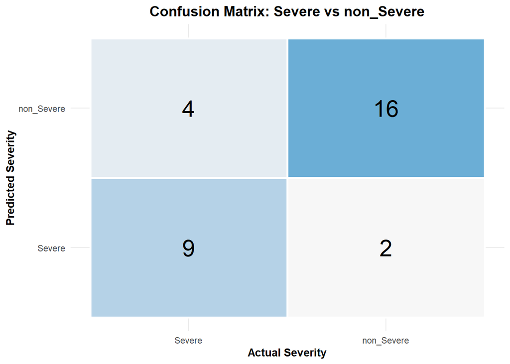

```r
# Plot 1: Visual Confusion Matrix (Square Heatmap)
cm_df <- as.data.frame(conf_mat$table)
cm_plot <- ggplot(data = cm_df, aes(x = Reference, y = Prediction, fill = Freq)) +
  geom_tile(color = "white", linewidth = 1) +
  geom_text(aes(label = Freq), size = 8, color = "black") +
  scale_fill_gradient(low = "#f7f7f7", high = "#6baed6") +
  theme_minimal() +
  labs(title = "Confusion Matrix: Severe vs non_Severe",
       x = "Actual Severity",
       y = "Predicted Severity") +
  theme(plot.title = element_text(hjust = 0.5, face = "bold", size = 14),
        axis.title = element_text(face = "bold"),
        legend.position = "none") # Hide the legend since the numbers are explicitly printed
print(cm_plot)
```

```r
# === ROC Curve and AUC ===
cat("\n=== ROC Curve and AUC ===\n")
```

```
=== ROC Curve and AUC ===
```

```r
# Calculate ROC using the probabilities of the 'Severe' class
roc_obj <- roc(response = cv_predictions$obs,
               predictor = cv_predictions$Severe,
               levels = rev(levels(cv_predictions$obs)))

cat("Area under the curve (AUC):", round(auc(roc_obj), 4), "\n")
```

```
Area under the curve (AUC): 0.9103
```

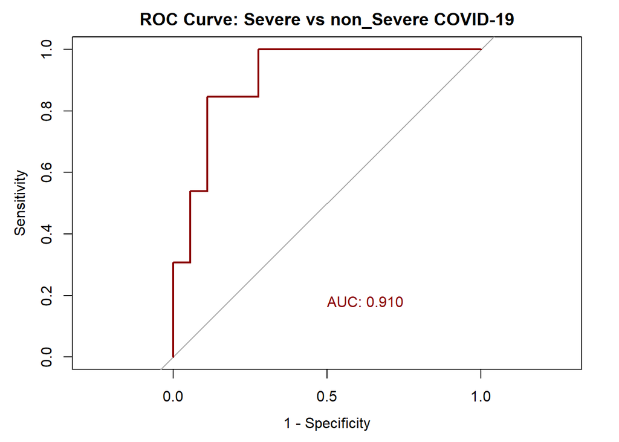

```r
# Plot 2: ROC Curve
plot(roc_obj,
     main = "ROC Curve: Severe vs non_Severe COVID-19",
     col = "darkred",
     lwd = 2,
     legacy.axes = TRUE,
     print.auc = TRUE,
     print.auc.y = 0.2)
```

```r
# === Additional Model Diagnostics ===
cat("\n=== Model Tuning & Variable Importance ===\n")
```

```
=== Model Tuning & Variable Importance ===
```

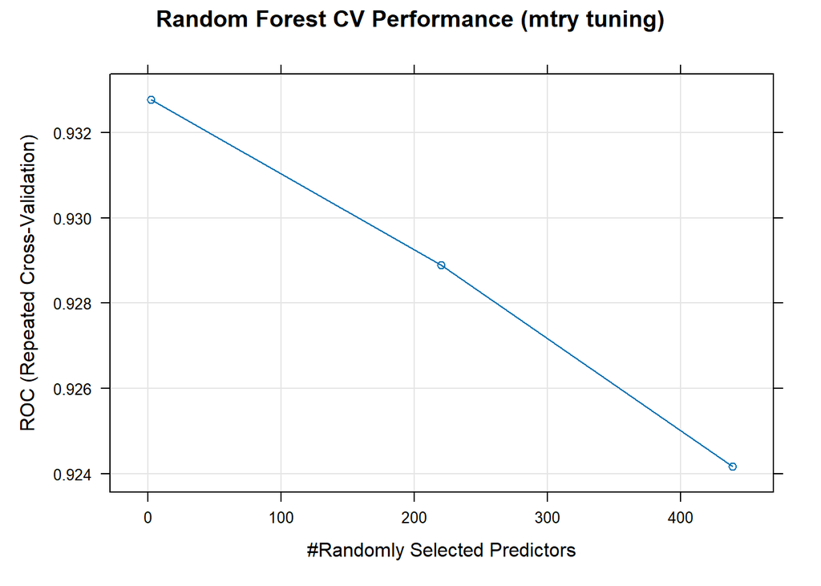

```r
# Plot 3: Cross-validation performance across tuning parameters (mtry)
plot(rf_fit, main = "Random Forest CV Performance (mtry tuning)")
```

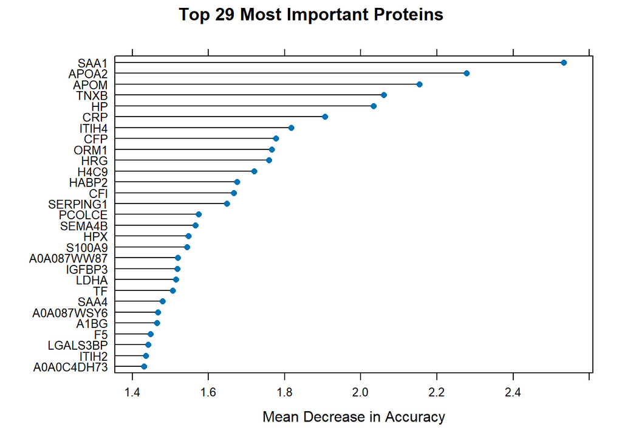

```r
# Plot 4: Top 29 Variable Importance
# Shows which proteins/metabolites were most critical for the classification
var_imp <- caret::varImp(rf_fit, scale = FALSE)
plot(var_imp, top = 29, main = "Top 29 Most Important Proteins", xlab = "Mean Decrease in Accuracy")
```

> **Note:** In the paper the RF was trained both with proteins and metabolites. The task specifically said “based on proteomic data”, so we excluded metabolites. This can cause major differences in the models.

> **Caveats:**
> 1. We use different data cleaning and imputation than in the paper.
> 2. We used median imputation rather than the methods used in the paper.
> 3. We imputed and scaled in each data split rather than globally to prevent data leakage — the paper does not explicitly state this.
> 4. We had to reduce certain RF parameters to keep the running time reasonable with our limit of 6 CPUs.

> **Results:**

> **Confusion Matrix:** Four false negatives and two false positives, against the one false positive in the paper. **Accuracy:** 0.8065 against 0.935 in the original paper — lower, but acceptable. **mTRY:** Rather smooth drop, meaning the model is not only relying on a few strong features but is actually learning a general pattern. **AUC/ROC:** AUC is 0.9103 against 0.957 in the original paper. Lower than the original but falls in the same relative range — meaning if we draw a random severe patient alongside a random non-severe, the model gives more “risk” to the severe patient 91% of the time. The ROC rises sharply, meaning as the decision threshold rises, sensitivity improves yet specificity does not drop significantly. The model can differentiate groups quite well by allocating risk correctly.

# Exercise 2

**Identify and interpret the most important features**

Using the trained Random Forest model from Exercise 1, identify the 25 most important protein features contributing to the classification. Disccuss their biological relevance.

Compare your selected features to the proteins reported by the authors in Supplementary Table 5.

```r
# 1. Install required packages for direct mapping
if (!requireNamespace("BiocManager", quietly = TRUE)) install.packages("BiocManager")
if (!requireNamespace("reactome.db", quietly = TRUE)) BiocManager::install("reactome.db", update = FALSE)
if (!requireNamespace("reshape2", quietly = TRUE)) install.packages("reshape2")
if (!requireNamespace("ggplot2", quietly = TRUE)) install.packages("ggplot2")

library(reactome.db)
library(org.Hs.eg.db)
library(ggplot2)
library(reshape2)

cat("\n=== Extracting Top 25 Proteins ===\n")
```

```
=== Extracting Top 25 Proteins ===
```

```r
# 2. Extract Top 25 PROTEIN Features
imp_df <- caret::varImp(rf_fit, scale = FALSE)$importance
imp_df$R_Name <- rownames(imp_df)

feature_map <- data.frame(
  R_Name = valid_protein_names,
  Symbol = mapped_symbols,
  Original_ID = original_features
)

imp_mapped <- merge(imp_df, feature_map, by = "R_Name")
imp_mapped <- imp_mapped[order(-imp_mapped[, 2]), ]
imp_proteins_only <- imp_mapped[!is.na(imp_mapped$Symbol), ]

# Get the Top 25 Symbols
top25_symbols <- imp_proteins_only$Symbol[1:25]

# 3. Map Symbols to Entrez IDs (Reactome uses Entrez)
entrez_mapping <- mapIds(org.Hs.eg.db, keys = top25_symbols, column = "ENTREZID", keytype = "SYMBOL", multiVals = "first")
# Create a dataframe to keep track of Symbol to Entrez relationship
mapping_df <- data.frame(
  Symbol = names(entrez_mapping),
  Entrez = unname(entrez_mapping),
  stringsAsFactors = FALSE
)
mapping_df <- mapping_df[!is.na(mapping_df$Entrez), ]

# 4. Direct 1:1 Query to Reactome Database
cat("\nQuerying Reactome Database directly...\n")
```

```
Querying Reactome Database directly...
```

```r
pathway_data <- suppressMessages(
  AnnotationDbi::select(
    reactome.db,
    keys = mapping_df$Entrez,
    columns = "PATHNAME",
    keytype = "ENTREZID"
  )
)

# Clean up the Reactome pathway names (Remove the "Homo sapiens: " prefix)
pathway_data$PATHNAME <- gsub("^Homo sapiens: ", "", pathway_data$PATHNAME)

# Merge back the Gene Symbols for readability
pathway_data <- merge(pathway_data, mapping_df, by.x = "ENTREZID", by.y = "Entrez")

# ==========================================
# 5. Filter for the Most Relevant Pathways & FORCE ALL 25 GENES
# ==========================================
pathway_counts <- sort(table(pathway_data$PATHNAME), decreasing = TRUE)
top_pathways <- names(pathway_counts)[1:10]

# Filter our data to only include these top pathways
plot_data <- pathway_data[pathway_data$PATHNAME %in% top_pathways, ]

# FIX 1: Explicitly turn the Symbol column into a factor that contains ALL 25 original genes
plot_data$Symbol <- factor(plot_data$Symbol, levels = top25_symbols)

# Wrap long pathway names so they don't get cut off on the y-axis
plot_data$PATHNAME_wrapped <- sapply(plot_data$PATHNAME, function(x) {
  paste(strwrap(x, width = 45), collapse = "\n")
})

# Order the pathways by prominence
wrapped_counts <- sort(table(plot_data$PATHNAME_wrapped), decreasing = FALSE)
plot_data$PATHNAME_wrapped <- factor(plot_data$PATHNAME_wrapped, levels = names(wrapped_counts))


# ==========================================
# 6. Plotting and Exporting the Gene-to-Pathway Map
# ==========================================
cat("\nGenerating Direct Pathway Map...\n")
```

```
Generating Direct Pathway Map...
```

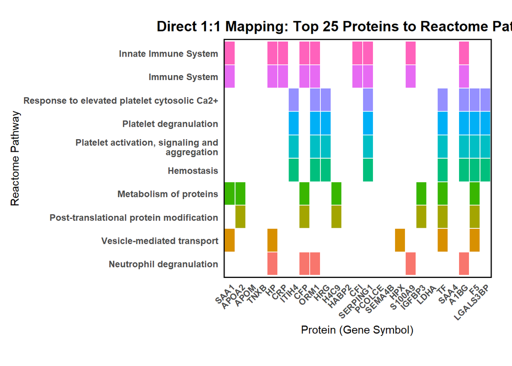

```r
p_map <- ggplot(plot_data, aes(x = Symbol, y = PATHNAME_wrapped, fill = PATHNAME_wrapped)) +
  geom_tile(color = "white", size = 0.5) +
  theme_minimal() +
  # FIX 2: scale_x_discrete(drop = FALSE) forces ggplot to show all 25 genes, even empty ones!
  scale_x_discrete(drop = FALSE) +
  labs(
    title = "Direct 1:1 Mapping: Top 25 Proteins to Reactome Pathways",
    x = "Protein (Gene Symbol)",
    y = "Reactome Pathway"
  ) +
  theme(
    axis.text.x = element_text(angle = 45, hjust = 1, vjust = 1, face = "bold"),
    axis.text.y = element_text(size = 9, face = "bold"),
    plot.title = element_text(face = "bold", size = 14, hjust = 0.5),
    # Extra bottom margin to ensure X-axis text fits
    plot.margin = ggplot2::margin(t = 20, r = 20, b = 30, l = 10),
    panel.grid.major = element_blank(),
    panel.grid.minor = element_blank(),
    panel.border = element_rect(color = "black", fill = NA, size = 1),
    legend.position = "none"
  )

print(p_map)
```

```r
# FIX 3: Save a perfectly sized, uncropped PNG to your working directory
ggsave("Top25_Reactome_Map.png", plot = p_map, width = 12, height = 8, dpi = 300)
cat("\nPlot saved successfully as 'Top25_Reactome_Map.png' in your working directory!\n")
```

```
Plot saved successfully as 'Top25_Reactome_Map.png' in your working directory!
```

```r
# 1. Load the paper's protein list from mmc5.xlsx
# We use the 'range' argument to strictly grab columns A and B, rows 3 to 24
paper_data <- readxl::read_excel(
  "mmc5.xlsx",
  sheet = "Prot_and_meta_matrix",
  range = "A3:B24",
  col_names = c("Uniprot_ID", "HGNC_Symbol")
)

cat("\n=== Comparing Top 25 Proteins to Paper's Supplementary Table 5 ===\n")
```

```
=== Comparing Top 25 Proteins to Paper's Supplementary Table 5 ===
```

```r
# 2. Extract and clean the paper's HGNC symbols
paper_symbols <- na.omit(paper_data$HGNC_Symbol)
paper_symbols <- unique(as.character(paper_symbols))

# 3. Find the overlap with our model's Top 25 proteins
# (top25_symbols was created and saved in Chunk 5)
overlapping_proteins <- intersect(top25_symbols, paper_symbols)
num_overlap <- length(overlapping_proteins)

# 4. Print the comparison results
cat(sprintf("Number of overlapping proteins: %d out of the %d reported in the paper\n\n",
            num_overlap, length(paper_symbols)))
```

```
Number of overlapping proteins: 6 out of the 22 reported in the paper
```

```r
cat("The overlapping proteins are:\n")
```

```
The overlapping proteins are:
```

```r
print(overlapping_proteins)
```

```
[1] "SAA1"     "HP"       "CRP"      "HABP2"    "SERPING1" "F5"
```

```r
# Let's also see what the paper found that our top 25 missed
missed_by_us <- setdiff(paper_symbols, top25_symbols)
cat("\nProteins highlighted by the paper but NOT in our Top 25:\n")
```

```
Proteins highlighted by the paper but NOT in our Top 25:
```

```r
print(missed_by_us)
```

```
 [1] "CFB"       "SERPINA3"  "C9"        "LRG1"      "ALB"       "CLEC3B"
 [7] "SAA2"      "C6"        "LCP1"      "CPN1"      "LBP"       "LUM"
[13] "ITIH3"     "OAF"       "PGLYRP2"   "SERPINA10"
```

```r
# And what our model prioritized that the paper didn't include in their strict list
extra_in_ours <- setdiff(top25_symbols, paper_symbols)
cat("\nProteins in our Top 25 but NOT in the paper's main list:\n")
```

```
Proteins in our Top 25 but NOT in the paper's main list:
```

```r
print(extra_in_ours)
```

```
 [1] "APOA2"    "APOM"     "TNXB"     "ITIH4"    "CFP"      "ORM1"
 [7] "HRG"      "H4C9"     "CFI"      "PCOLCE"   "SEMA4B"   "HPX"
[13] "S100A9"   "IGFBP3"   "LDHA"     "TF"       "SAA4"     "A1BG"
[19] "LGALS3BP"
```

# Exercise 3

**External prediction on an independent test cohort**

Using the final Random Forest model trained on the full training cohort, predict disease severity for patients in the independent test cohort provided in Supplementary Table 4.

Your task is to:

- Apply the trained model to the test cohort.
- Obtain predicted probabilities of Severe disease for each patient.
- Assign predicted class labels based on these probabilities.
- Compare predictions to the true clinical labels.

How does the model perform on the independent test cohort?

> To apply the model to an independent test cohort, we first need to retrain it on 100% of the training data in Cohort 1 (C1) — without cross-validation — so that the model has learned from all available training samples before making predictions. The test cohort (Supplementary Table 4, C2) contains 10 patients (4 Severe and 6 Non-severe) with their own proteomic profiles. We align features between the two cohorts, impute any missing proteins, and evaluate performance using a confusion matrix, accuracy, and AUC.

```r
#We repeat the same training as in exercise one, but this time we train the model on 100% of the data in C1 (we skip the cross-validation)

# ==========================================
# CHUNK 1: Data Import
# ==========================================
if (!requireNamespace("readxl", quietly = TRUE)) {
  install.packages("readxl")
}
library(readxl)

# Automatically set working directory to the script's location (requires RStudio)
if (requireNamespace("rstudioapi", quietly = TRUE) && rstudioapi::isAvailable()) {
  setwd(dirname(rstudioapi::getActiveDocumentContext()$path))
}

# Import proteomics data
df <- read_excel("mmc3.xlsx", sheet = "Prot_and_meta_matrix", col_names = FALSE)

# KEEP ONLY PROTEINS: Subset to rows 1 through 793 (metabolites start at 794)
df <- df[1:793, ]

# Drop column 2
df <- df[, -2]

# Move cell (1,1) to (2,1), remove row 1, set new row 1 as colnames, then remove it
df[2, 1] <- df[1, 1]
df <- df[-1, ]
colnames(df) <- as.character(df[1, ])
df <- df[-1, ]


# ==========================================
# CHUNK 2: Filtering (NO GLOBAL IMPUTATION)
# ==========================================
# To prevent data leakage, we ONLY perform basic missingness filtering here.
# Imputation and scaling are deferred to the CV resampling loop in Chunk 4.

# Convert patient columns to numeric
df[, -1] <- lapply(df[, -1], as.numeric)

# 1. Filter rows (Proteins/Metabolites) with > 20% missing values
row_missing_frac <- rowMeans(is.na(df[, -1]))
df <- df[row_missing_frac <= 0.20, ]

# 2. Filter columns (Patients) with > 20% missing values
col_missing_frac <- colMeans(is.na(df[, -1]))
df <- df[, c(TRUE, col_missing_frac <= 0.20)]


# ==========================================
# CHUNK 3: Import Metadata and Map to Proteomics Data
# ==========================================
# 1. Import the metadata file
labels_raw <- read_excel("data.xlsx", sheet = "Clinical_information")

# 2. Extract Column 1 (Patient IDs) and Column 5 (Severity scores)
meta_labels <- labels_raw[, c(1, 5)]

# Rename columns to make them easier to work with
colnames(meta_labels) <- c("PatientID", "Severity")
meta_labels$Severity <- as.numeric(meta_labels$Severity)

# 3. Filter rows: Keep only values 2 and 3
meta_labels <- meta_labels[meta_labels$Severity %in% c(2, 3), ]

# 4. Recode 2 as "non-Severe" and 3 as "Severe"
meta_labels$Severity <- ifelse(meta_labels$Severity == 2, "non-Severe", "Severe")

# 5. Map labels to the proteomics dataframe (df)
# Get the patient IDs currently in our proteomics dataframe (excluding column 1)
df_patients <- colnames(df)[-1]

# Find the intersection (patients that exist in BOTH 'df' and 'meta_labels')
common_patients <- intersect(df_patients, meta_labels$PatientID)

# Filter 'meta_labels' to only include the common patients
meta_labels <- meta_labels[meta_labels$PatientID %in% common_patients, ]

# Filter 'df' to keep the first column ("Protein/Metabolites") AND the common patients
df <- df[, c(colnames(df)[1], common_patients)]

# Print a quick check
cat("Number of matched patients:", length(common_patients), "\n")
```

```
Number of matched patients: 31
```

```r
head(meta_labels)
```

```
# A tibble: 6 × 2
  PatientID Severity
  <chr>     <chr>
1 XG1       non-Severe
2 XG2       non-Severe
3 XG3       non-Severe
4 XG4       non-Severe
5 XG5       non-Severe
6 XG6       non-Severe
```

```r
# ==========================================
# CHUNK 4: Random Forest Modeling (Full Data)
# ==========================================

# Install and load required packages
if (!requireNamespace("caret", quietly = TRUE)) install.packages("caret")
if (!requireNamespace("randomForest", quietly = TRUE)) install.packages("randomForest")
if (!requireNamespace("pROC", quietly = TRUE)) install.packages("pROC")
if (!requireNamespace("ggplot2", quietly = TRUE)) install.packages("ggplot2")
if (!requireNamespace("doParallel", quietly = TRUE)) install.packages("doParallel")

# Add Bioconductor packages for ID mapping
if (!requireNamespace("BiocManager", quietly = TRUE)) install.packages("BiocManager")
if (!requireNamespace("AnnotationDbi", quietly = TRUE)) BiocManager::install("AnnotationDbi", update = FALSE)
if (!requireNamespace("org.Hs.eg.db", quietly = TRUE)) BiocManager::install("org.Hs.eg.db", update = FALSE)

library(caret)
library(randomForest)
library(pROC)
library(ggplot2)
library(doParallel)
library(AnnotationDbi)
library(org.Hs.eg.db)

# 1. Prepare data for modeling (Transpose and Map IDs)
original_features <- as.character(df[[1]])

# Attempt to map UniProt IDs to HGNC Symbols
suppressMessages({
  mapped_symbols <- mapIds(
    org.Hs.eg.db,
    keys = original_features,
    column = "SYMBOL",
    keytype = "UNIPROT",
    multiVals = "first"
  )
})

# Replace with HGNC symbol if a mapping was found, otherwise keep original name
updated_features <- ifelse(is.na(mapped_symbols), original_features, mapped_symbols)

# R models require valid column names without spaces or special characters
valid_protein_names <- make.names(updated_features, unique = TRUE)

# Transpose dataframe (exclude the first column of IDs)
df_t <- as.data.frame(t(df[, -1]))
colnames(df_t) <- valid_protein_names

# Add PatientID back in for merging
df_t$PatientID <- rownames(df_t)

# 2. Merge labels and transposed proteomics data
# Set explicitly to factors with "Severe" as the first level (the positive class)
meta_labels$Severity <- factor(gsub("-", "_", meta_labels$Severity), levels = c("Severe", "non_Severe"))
model_data <- merge(meta_labels, df_t, by = "PatientID")

# Drop the PatientID column as it shouldn't be used as a predictor feature
model_data$PatientID <- NULL


# 3. Set up Parallel Processing (Allocate 6 Cores)
cat("\nSetting up parallel processing with 6 cores...\n")
```

```
Setting up parallel processing with 6 cores...
```

```r
cl <- makePSOCKcluster(6)
registerDoParallel(cl)

# 4. Set up Training Control for Full Data (method = "none")
set.seed(123)
fitControl <- caret::trainControl(
  method = "none",                     # Instructs caret to use all data and skip resampling
  classProbs = TRUE,                   # Keep to predict probabilities later
  allowParallel = TRUE                 # Enable parallel processing
)

# Because we aren't resampling, we must explicitly define the tuning parameter 'mtry'.
# The standard default for classification is the square root of the number of predictors.
num_predictors <- ncol(model_data) - 1
mtry_val <- floor(sqrt(num_predictors))
rf_grid <- data.frame(mtry = mtry_val)

# 5. Train the Final Random Forest Model on 100% of the Data
cat("\nTraining Random Forest on the entire dataset (Running in parallel)...\n")
```

```
Training Random Forest on the entire dataset (Running in parallel)...
```

```r
rf_fit <- caret::train(
  Severity ~ .,
  data = model_data,
  method = "rf",
  trControl = fitControl,
  tuneGrid = rf_grid,                                 # Must provide exact tuning grid when method="none"
  preProcess = c("medianImpute", "center", "scale"),  # Applied globally to the whole dataset now
  ntree = 1000,
  importance = TRUE,
  na.action = na.pass                                 # Allows NAs to pass to preProcess
)

# Stop the parallel cluster after training is complete
stopCluster(cl)
registerDoSEQ()
cat("\nModel training complete. Parallel cluster stopped.\n")
```

```
Model training complete. Parallel cluster stopped.
```

```r
# ==========================================
# CHUNK 5: Test Cohort Import
# ==========================================
cat("\nImporting test cohort (mmc4.xlsx)...\n")
```

```
Importing test cohort (mmc4.xlsx)...
```

```r
df_test <- read_excel("mmc4.xlsx", sheet = "Prot_and_meta_matrix", col_names = FALSE)

# Keep ONLY up to row 744 (Proteins only, discarding metabolites below)
df_test <- df_test[1:744, ]

# Drop column 2
df_test <- df_test[, -2]

# Format headers exactly like the training data
df_test[2, 1] <- df_test[1, 1]
df_test <- df_test[-1, ]
colnames(df_test) <- as.character(df_test[1, ])
df_test <- df_test[-1, ]

# Convert patient columns to numeric
df_test[, -1] <- lapply(df_test[, -1], as.numeric)

# ==========================================
# CHUNK 6: Map Test Patients to Metadata
# ==========================================
# We must re-import the metadata because we previously filtered it down to only training patients
labels_raw_test <- read_excel("data.xlsx", sheet = "Clinical_information")

meta_test <- labels_raw_test[, c(1, 5)]
colnames(meta_test) <- c("PatientID", "Severity")

# FIX: Safely convert to character instead of numeric to prevent NAs
meta_test$Severity <- as.character(meta_test$Severity)

# Standardize all possible labels (numbers or text) to exactly "Severe" and "non_Severe"
meta_test$Severity[meta_test$Severity == "2"] <- "non_Severe"
meta_test$Severity[meta_test$Severity == "3"] <- "Severe"
meta_test$Severity[meta_test$Severity == "non-Severe"] <- "non_Severe" # In case of hyphens

# Filter to keep ONLY our two valid classes
meta_test <- meta_test[meta_test$Severity %in% c("Severe", "non_Severe"), ]
meta_test$Severity <- factor(meta_test$Severity, levels = c("Severe", "non_Severe"))

# Find the intersection for the TEST cohort
test_patients <- colnames(df_test)[-1]
common_test_patients <- intersect(test_patients, meta_test$PatientID)

# Filter
meta_test <- meta_test[meta_test$PatientID %in% common_test_patients, ]
df_test <- df_test[, c(colnames(df_test)[1], common_test_patients)]

cat("Number of matched TEST patients:", length(common_test_patients), "\n")
```

```
Number of matched TEST patients: 10
```

```r
# ==========================================
# CHUNK 7: Test Prediction & Evaluation
# ==========================================
# 1. Map IDs to HGNC Symbols (Same as Training)
original_features_test <- as.character(df_test[[1]])

suppressMessages({
  mapped_symbols_test <- mapIds(
    org.Hs.eg.db,
    keys = original_features_test,
    column = "SYMBOL",
    keytype = "UNIPROT",
    multiVals = "first"
  )
})

updated_features_test <- ifelse(is.na(mapped_symbols_test), original_features_test, mapped_symbols_test)
valid_protein_names_test <- make.names(updated_features_test, unique = TRUE)

# Transpose
df_test_t <- as.data.frame(t(df_test[, -1]))
colnames(df_test_t) <- valid_protein_names_test
df_test_t$PatientID <- rownames(df_test_t)

# Merge labels
test_data <- merge(meta_test, df_test_t, by = "PatientID")

# Keep a record of the IDs, then drop from predictors
test_patient_ids <- test_data$PatientID
test_data$PatientID <- NULL

# 2. ALIGN FEATURES (Crucial Step - WITH FIX APPLIED)
# The test data is missing metabolites and possibly some proteins that didn't map.
# We must add these missing columns as NAs so caret can impute them based on training medians.
train_features <- rf_fit$coefnames
missing_features <- setdiff(train_features, colnames(test_data))

if (length(missing_features) > 0) {
  # FIX: Use NA_real_ so the new columns are created as numeric, not logical
  test_data[missing_features] <- NA_real_
  cat("\nAdded", length(missing_features), "missing features as NAs to test data for imputation.\n")
}
```

```
Added 11 missing features as NAs to test data for imputation.
```

```r
# FIX: Force all predictor columns to be explicitly numeric
# (Transposing a dataframe can sometimes secretly turn numbers into characters)
predictor_cols <- setdiff(colnames(test_data), "Severity")
test_data[predictor_cols] <- lapply(test_data[predictor_cols], as.numeric)

# 3. GENERATE PREDICTIONS
cat("\nApplying trained model to the test cohort...\n")
```

```
Applying trained model to the test cohort...
```

```r
# Get Predicted Probabilities (Crucial: na.action = na.pass stops it from deleting NA rows)
test_probs <- predict(rf_fit, newdata = test_data, type = "prob", na.action = na.pass)

# Get Predicted Class Labels (Threshold = 0.5)
test_preds <- predict(rf_fit, newdata = test_data, na.action = na.pass)

# Create a clean dataframe showing individual patient results
patient_results <- data.frame(
  PatientID = test_patient_ids,
  True_Label = test_data$Severity,
  Predicted_Label = test_preds,
  Prob_Severe = test_probs$Severe
)

# 4. EVALUATE PERFORMANCE
cat("\n--- Independent Test Cohort Confusion Matrix ---\n")
```

```
--- Independent Test Cohort Confusion Matrix ---
```

```r
conf_matrix <- confusionMatrix(data = test_preds, reference = test_data$Severity, positive = "Severe")
print(conf_matrix)
```

```
Confusion Matrix and Statistics

            Reference
Prediction   Severe non_Severe
  Severe          3          3
  non_Severe      1          3

               Accuracy : 0.6
                 95% CI : (0.2624, 0.8784)
    No Information Rate : 0.6
    P-Value [Acc > NIR] : 0.6331

                  Kappa : 0.2308

 Mcnemar's Test P-Value : 0.6171

            Sensitivity : 0.750
            Specificity : 0.500
         Pos Pred Value : 0.500
         Neg Pred Value : 0.750
             Prevalence : 0.400
         Detection Rate : 0.300
   Detection Prevalence : 0.600
      Balanced Accuracy : 0.625

       'Positive' Class : Severe
```

```r
# Calculate and print Area Under the Curve (AUC) - FIXED DIRECTION
roc_obj <- suppressMessages(roc(test_data$Severity, test_probs$Severe, levels = c("non_Severe", "Severe")))
cat("\nTrue Test Cohort AUC:", auc(roc_obj), "\n")
```

```
True Test Cohort AUC: 0.7916667
```

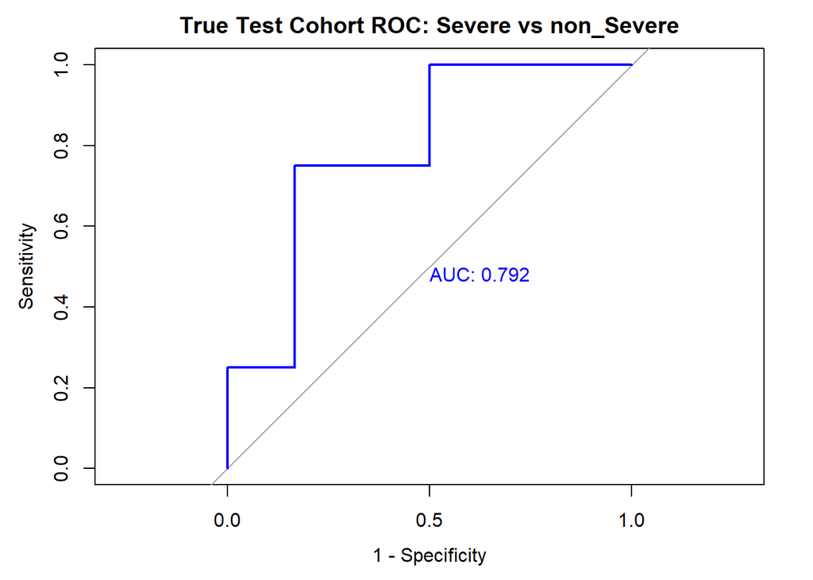

```r
# Plot the real ROC curve
plot(roc_obj, main = "True Test Cohort ROC: Severe vs non_Severe", col = "blue", lwd = 2, legacy.axes = TRUE, print.auc = TRUE)
```

```r
# Find the mathematical optimal threshold from the ROC curve
coords(roc_obj, "best", ret = c("threshold", "accuracy", "sensitivity", "specificity"))
```

```
          threshold accuracy sensitivity specificity
threshold    0.6215      0.8        0.75   0.8333333
```

> This tells us that in this particular test cohort, 0.62 would actually be the optimal threshold. In real ML research this can be done during training to identify a non-arbitrary yet generalizable threshold.

# session info

R version 4.5.1 (2025-06-13 ucrt) Platform: x86_64-w64-mingw32/x64 Running under: Windows 11 x64 (build 26200)

Matrix products: default LAPACK version 3.12.1

locale: [1] LC_COLLATE=English_India.utf8 LC_CTYPE=English_India.utf8  
[3] LC_MONETARY=English_India.utf8 LC_NUMERIC=C  
[5] LC_TIME=English_India.utf8

time zone: Europe/Paris tzcode source: internal

attached base packages: [1] stats4 parallel stats graphics grDevices utils datasets [8] methods base

other attached packages: [1] reshape2_1.4.5 reactome.db_1.92.0 org.Hs.eg.db_3.21.0 [4] AnnotationDbi_1.70.0 IRanges_2.42.0 S4Vectors_0.46.0  
[7] Biobase_2.68.0 BiocGenerics_0.54.1 generics_0.1.4  
[10] doParallel_1.0.17 iterators_1.0.14 foreach_1.5.2  
[13] pROC_1.19.0.1 randomForest_4.7-1.2 caret_7.0-1  
[16] lattice_0.22-7 ggplot2_4.0.1 readxl_1.4.5

loaded via a namespace (and not attached): [1] DBI_1.3.0 rlang_1.1.7 magrittr_2.0.4  
[4] otel_0.2.0 e1071_1.7-17 compiler_4.5.1  
[7] RSQLite_2.4.6 png_0.1-8 vctrs_0.6.5  
[10] stringr_1.6.0 pkgconfig_2.0.3 crayon_1.5.3  
[13] fastmap_1.2.0 XVector_0.48.0 labeling_0.4.3  
[16] utf8_1.2.6 rmarkdown_2.30 prodlim_2026.03.11  
[19] UCSC.utils_1.4.0 purrr_1.2.0 bit_4.6.0  
[22] xfun_0.54 cachem_1.1.0 GenomeInfoDb_1.44.3  
[25] jsonlite_2.0.0 recipes_1.3.1 blob_1.3.0  
[28] R6_2.6.1 bslib_0.10.0 stringi_1.8.7  
[31] RColorBrewer_1.1-3 parallelly_1.46.1 rpart_4.1.24  
[34] lubridate_1.9.5 jquerylib_0.1.4 cellranger_1.1.0  
[37] Rcpp_1.1.0 knitr_1.51 future.apply_1.20.2  
[40] Matrix_1.7-4 splines_4.5.1 nnet_7.3-20  
[43] timechange_0.4.0 tidyselect_1.2.1 rstudioapi_0.18.0  
[46] yaml_2.3.10 timeDate_4052.112 codetools_0.2-20  
[49] listenv_0.10.0 tibble_3.3.0 plyr_1.8.9  
[52] withr_3.0.2 KEGGREST_1.48.1 S7_0.2.0  
[55] evaluate_1.0.5 future_1.69.0 survival_3.8-6  
[58] proxy_0.4-29 Biostrings_2.76.0 pillar_1.11.1  
[61] BiocManager_1.30.27 scales_1.4.0 globals_0.19.0  
[64] class_7.3-23 glue_1.8.0 tools_4.5.1  
[67] data.table_1.17.8 ModelMetrics_1.2.2.2 gower_1.0.2  
[70] grid_4.5.1 ipred_0.9-15 nlme_3.1-168  
[73] GenomeInfoDbData_1.2.14 cli_3.6.5 rematch_2.0.0  
[76] lava_1.8.2 dplyr_1.1.4 gtable_0.3.6  
[79] sass_0.4.10 digest_0.6.37 farver_2.1.2  
[82] memoise_2.0.1 htmltools_0.5.8.1 lifecycle_1.0.5  
[85] hardhat_1.4.2 httr_1.4.8 bit64_4.6.0-1  
[88] MASS_7.3-65